# Анализ аспектов оценки коротких историй

## Данные

Данные представляют собой результаты оценки коротких историй по 9 критериям. Оставим в данных только сами критерии, удалив ненужные на данный момент колонки. Критерии оценивались по разным шкалам, что отображено в саммари.

*Шкала 0 - 4*

**overall_quality_rating** – главный критерий; общая оценка качества истории.  
**coherency_score** – последовательность и логичность событий.  
**fluency_score** – естественность и грамматичность языка.  
**interest_score** – насколько история интересна.

*Шкала 0 - 1*

**narrative_arc_answer** – наличие нарративной арки.  
**common_sense_answer** – соответствие истории здравому смыслу.  
**plot_twist_answer** – наличие неожиданной смены событий.  
**humanlike_score** – насколько история похожа на написанную человеком.

*Шкала 0 - 2*

**share_score** – желание поделиться историей с другими (да/не уверен/нет).

```r
data <- read_csv('https://raw.githubusercontent.com/yashkens/AnDan_CompLing_Project/main/story_evaluation_scores.csv', show_col_types = FALSE)

to_delete = c('story', 'Human', 'NLI', 'Emo', 'EmoArc', 'ATD')
data = data[ , !(names(data) %in% to_delete)]
summary(data, digits = 2)
```

```
##  overall_quality_rating narraive_arc_answer common_sense_answer coherency_score
##  Min.   :0.0            Min.   :0.00        Min.   :0.00        Min.   :0.0
##  1st Qu.:1.6            1st Qu.:0.20        1st Qu.:0.40        1st Qu.:2.0
##  Median :2.4            Median :0.60        Median :0.60        Median :2.8
##  Mean   :2.3            Mean   :0.58        Mean   :0.59        Mean   :2.7
##  3rd Qu.:3.0            3rd Qu.:0.80        3rd Qu.:1.00        3rd Qu.:3.4
##  Max.   :4.0            Max.   :1.00        Max.   :1.00        Max.   :4.0
##  fluency_score interest_score plot_twist_answer  share_score   humanlike_score
##  Min.   :0.0   Min.   :0.0    Min.   :0.0       Min.   :0.00   Min.   :0.00
##  1st Qu.:2.0   1st Qu.:1.6    1st Qu.:0.2       1st Qu.:0.40   1st Qu.:0.40
##  Median :2.6   Median :2.2    Median :0.4       Median :0.80   Median :0.60
##  Mean   :2.6   Mean   :2.2    Mean   :0.5       Mean   :0.89   Mean   :0.59
##  3rd Qu.:3.2   3rd Qu.:2.8    3rd Qu.:0.8       3rd Qu.:1.20   3rd Qu.:0.80
##  Max.   :4.0   Max.   :4.0    Max.   :1.0       Max.   :2.00   Max.   :1.00
```

Распределение интересующей нас переменной.

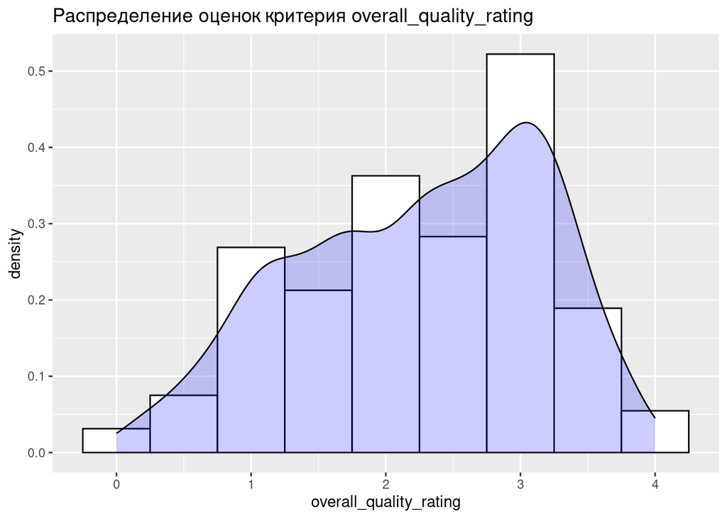

```r
ggplot(data, aes(x=overall_quality_rating)) +
  geom_histogram(aes(y=after_stat(density)), binwidth=.5, colour="black", fill="white") +
  geom_density(alpha=.2, fill="blue") +
  ggtitle("Распределение оценок критерия overall_quality_rating")
```

## Гипотеза

Создателям историй (как сгенерированных, так и написанных) важно понимать, какие истории нравятся читателям и почему. В этом исследовании изучим факторы, составляющие общую оценку и выясним, какой вклад вносит каждый из них.

**Гипотеза** – общий критерий *overall_quality_rating* независим от остальных критериев, которые рассматриваются в этой работе.  
**Альтернативная гипотеза** – общая оценка истории зависит от остальных критериев.

## Корреляция

Сначала посчитаем корреляцию Пирсона между всеми критериями. Примечательные заметки по графику:

- Наиболее высокая корреляция для критерия *overall_quality_rating* наблюдается с критерием последовательности, а также с критериями интересности и соответствия здравому смыслу.
- Критерий *plot_twist_answer* имеет самую низкую корреляцию с остальными факторами, но при этом заметно коррелирует с фактором *interest_score*.

Также выделяются следующие факты:

- Критерий *share_score* положительно коррелирует с *interest_score*.
- Критерий *fluency_score* положительно коррелирует с *humanlike_score*.
- Критерий *common_sense_answer* положительно коррелирует с *narrative_arc_answer*, что довольно сложно объяснить.

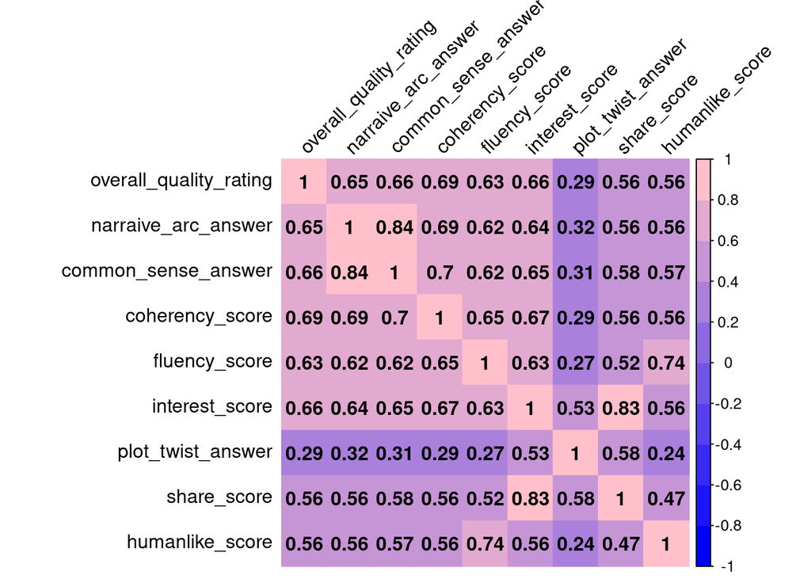

```r
corrplot(cor(data), method="color", addCoef.col = "black", tl.srt = 45, tl.col = "black", col= colorRampPalette(c("blue","pink"))(10))
```

## OLS Regression

Далее изучим линейную зависимость интересующего нас главного критерия *overall_quality_rating* со всеми остальными.

P-value < 0.05 для всех критериев, кроме двух – *plot_twist_answer* и *share_score*. Также p-value > 0.01 для критерия *humanlike_score*, что могло бы быть важно при более строгом пороге значимости.

Гипотеза подтвердилась для *plot_twist_answer* и *share_score* – общее качество истории не зависит от этих критериев, они не имеют значительного вклада в общую оценку.

Для остальных критериев нулевая гипотеза была отвергнута и принята альтернативная. То есть общая оценка истории статистически значимо зависит от оставшихся факторов. Все обнаруженные зависимости положительные, значит, при улучшении отдельных факторов ожидается рост общего качества.

```r
model <- lm(overall_quality_rating ~ ., data=data)
summary(model)
```

```
##
## Call:
## lm(formula = overall_quality_rating ~ ., data = data)
##
## Residuals:
##      Min       1Q   Median       3Q      Max
## -1.80390 -0.39683  0.02351  0.40799  2.09843
##
## Coefficients:
##                      Estimate Std. Error t value Pr(>|t|)
## (Intercept)          0.191804   0.064198   2.988 0.002865 **
## narraive_arc_answer  0.316955   0.094774   3.344 0.000849 ***
## common_sense_answer  0.353263   0.095883   3.684 0.000239 ***
## coherency_score      0.267321   0.029138   9.174  < 2e-16 ***
## fluency_score        0.139476   0.033340   4.183 3.07e-05 ***
## interest_score       0.239326   0.040846   5.859 5.92e-09 ***
## plot_twist_answer   -0.094051   0.071573  -1.314 0.189063
## share_score          0.002824   0.057906   0.049 0.961109
## humanlike_score      0.217575   0.085692   2.539 0.011234 *
## ---
## Signif. codes:  0 '***' 0.001 '**' 0.01 '*' 0.05 '.' 0.1 ' ' 1
##
## Residual standard error: 0.5802 on 1270 degrees of freedom
## Multiple R-squared:  0.5986, Adjusted R-squared:  0.596
## F-statistic: 236.7 on 8 and 1270 DF,  p-value: < 2.2e-16
```

Построим график, на котором наглядно показаны коэффициенты при каждом факторе в линейной зависимости.

Хотя мы выяснили, что общее качество не зависит от наличия неожиданного перехода (plot twist), интересно, что коэффициент этого фактора отрицательный.

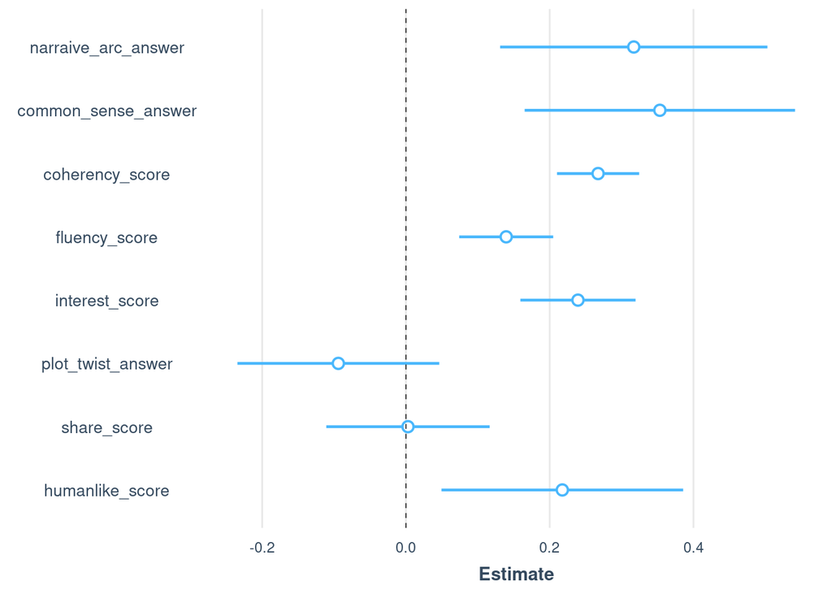

```r
plot_summs(model)
```

Проиллюстрируем линейную зависимость общей оценки от фактора *common_sense_answer*, который вносит наибольший положительных вклад, судя по коэффициентам.

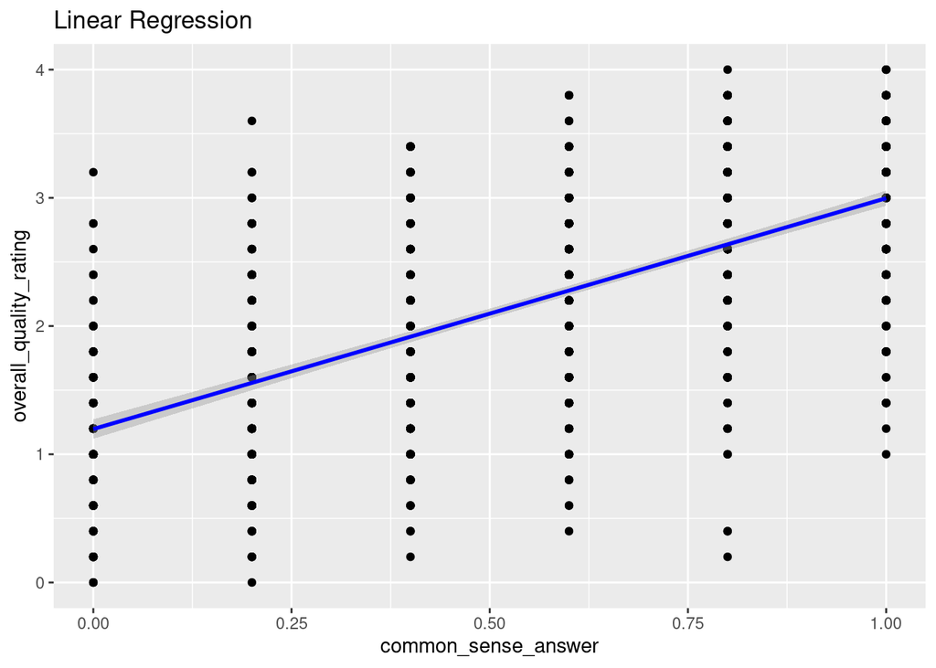

```r
ggplot(data, aes(x = common_sense_answer, y = overall_quality_rating)) +
  geom_point() +
  stat_smooth(method = "lm", formula = y ~ x, col = "blue") +
  ggtitle("Linear Regression")
```

## Зависимости между другими критериями

Мы выяснили зависимость общего качества истории от остальных критериев. Интересно изучить зависимости между другими критериями, понять, как каждый из них объясним с помощью других.

Выводы по этой табличке дублируют те, что были приведены в анализе таблички корреляции, поэтому я их опущу.

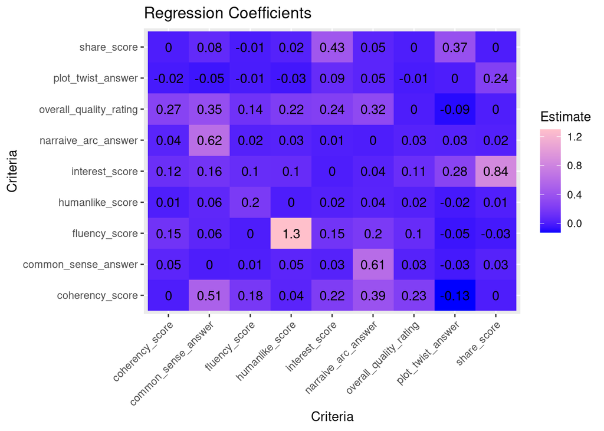

```r
criteria <- c(colnames(data))
full_df <- data.frame(Criteria=NA, Estimate=NA, Target=NA)[numeric(0), ]

for (i in seq_along(criteria)){
  crit = criteria[i]
  model <- lm(paste0(crit, '~', '.'), data=data)
  coefs <- summary(model)$coef
  coefs <- data.frame(Criteria=rownames(coefs), coefs)
  coefs_df <- coefs[c("Criteria","Estimate")]
  new_col = data.frame(Criteria=crit, Estimate=0)
  coefs_df <- coefs_df[-1, ]
  coefs_df <- coefs_df %>%
    add_row(new_col, .before=i)
  target <- rep(crit, nrow(coefs_df))
  coefs_df$Target <- target
  full_df <- rbind(full_df, coefs_df)
}

ggplot(full_df, aes(Criteria, Target)) +
  geom_tile(aes(fill = Estimate)) +
  geom_text(aes(label = round(Estimate, 2))) +
  scale_fill_gradient(low = "blue", high = "pink") +
  theme(axis.text.x = element_text(angle = 45, hjust=1)) +
  ggtitle("Regression Coefficients") +
  xlab("Criteria") + ylab("Criteria")
```

## Оценка сгенерированных и написанных людьми историй

В данных имеется информация о происхождении истории. Она могла быть написана человеком или могла быть сгенерированная языковой моделью.

Поставим нулеваю гипотезу, что написанные людьми не отличаются в общей оценке от тех, что были сгенерированы. Проведем тест Манна-Уитни, потому что данные распределены не нормально.

```r
data <- read_csv('https://raw.githubusercontent.com/yashkens/AnDan_CompLing_Project/main/story_evaluation_scores.csv', show_col_types = FALSE)
data <- data %>%
  select(overall_quality_rating, Human)

hum_data <- data %>%
  filter(Human == 1)
gen_data <- data %>%
  filter(Human == 0)

wilcox.test(hum_data$overall_quality_rating, gen_data$overall_quality_rating, paired = FALSE)
```

```
##
##  Wilcoxon rank sum test with continuity correction
##
## data:  hum_data$overall_quality_rating and gen_data$overall_quality_rating
## W = 330406, p-value < 2.2e-16
## alternative hypothesis: true location shift is not equal to 0
```

```r
mean(hum_data$overall_quality_rating)
```

```
## [1] 2.870056
```

```r
mean(gen_data$overall_quality_rating)
```

```
## [1] 1.82754
```